# Variation Stuff

Load the datasets:

```r
reaches <- read.csv('data/variation_reaches.csv', stringsAsFactors = F)
localizations <- read.csv('data/variation_localizations.csv', stringsAsFactors = F)
error.clamp.idx <- which(reaches$distortion == 360)
reaches$distortion[error.clamp.idx] <- NA
localizations$distortion[error.clamp.idx] <- NA
```

First we care mostly about the localizations. Just to be sure we baseline it first. (Doesn’t seem to matter much…)

```r
baseline <- function(reachvector,blidx) reachvector - mean(reachvector[blidx], na.rm=TRUE)
localizations[,2:ncol(localizations)] <- apply(localizations[,2:ncol(localizations)], FUN=baseline, MARGIN=c(2), blidx=c(24:49))
```

Let’s get the mean and a confidence interval for every trial:

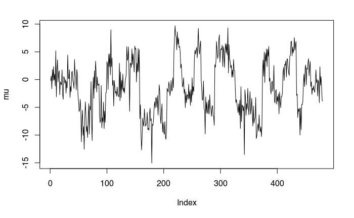

```r
mu <- apply(localizations[2:33], MARGIN=c(1), FUN=mean, na.rm=TRUE)
plot(mu, type='l')
```

Now, we scale it by the distortion:

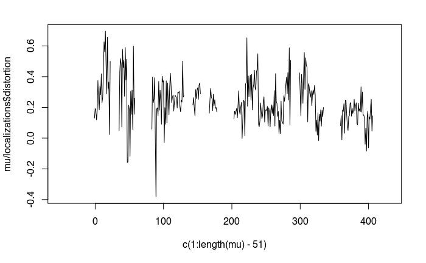

```r
plot(c(1:length(mu)-51), mu / localizations$distortion, type='l')
```

This looks like a decreasing line: the proportion does decrease when people experience a lot of changes in the distortion. Is it significant?

```r
timeProp <- data.frame('trial'=c(1:length(mu))-51, 'proportion'=mu/localizations$distortion)
# timeProp <- timeProp[which(localizations$distortion != 0),]  # division by 0 also results in infinite proportions:
timeProp <- timeProp[is.finite(timeProp$proportion),]
linearPropModel <- lm(proportion ~ trial, data=timeProp)
summary(linearPropModel)
```

```
Call:
lm(formula = proportion ~ trial, data = timeProp)

Residuals:
     Min       1Q   Median       3Q      Max
-0.65665 -0.07990 -0.00805  0.07994  0.41937

Coefficients:
              Estimate Std. Error t value Pr(>|t|)
(Intercept)  3.028e-01  1.698e-02  17.826  < 2e-16 ***
trial       -3.104e-04  7.002e-05  -4.433 1.32e-05 ***
---
Signif. codes:  0 ‘***’ 0.001 ‘**’ 0.01 ‘*’ 0.05 ‘.’ 0.1 ‘ ’ 1

Residual standard error: 0.1432 on 286 degrees of freedom
Multiple R-squared:  0.0643,    Adjusted R-squared:  0.06103
F-statistic: 19.65 on 1 and 286 DF,  p-value: 1.324e-05
```

So trial (time) explains part of the proportion: localization/rotation. Let’s look at the intercept at the first rotated trial:

```r
plot(-1000,-1000,main='proportion over time',xlab='rotated trial',ylab='proportion',xlim=c(0,430),ylim=c(-.4,+.8),bty='n')

lines(c(0,430),c(0,0))
```

```r
predicted <- predict(linearPropModel, newdata = data.frame('trial'=c(1:length(mu))), interval='confidence')
n <- dim(predicted)[1]

lines(c(51,length(mu))-51,c(0.2,0.2),col='blue',lty=2)

polygon(x=c(c(51:n)-50,rev(c(51:n)-50)), y=c(predicted[c(51:length(mu)),2], rev(predicted[c(51:length(mu)),3])), col="#ff00ff2f", border=NA)
```

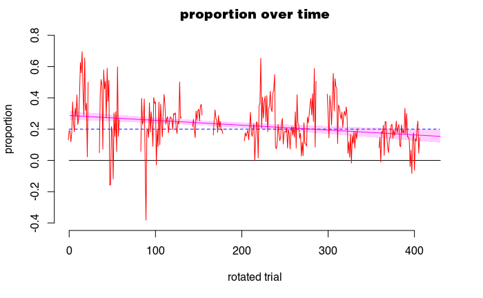

```r
lines(x=c(51:n)-50, y=predicted[c(51:length(mu)),1], col='#ff00ff')

lines(c(1:length(mu)-51), mu / localizations$distortion, type='l', col='red')
```

Let’s look at the immediacy of shifts in localization responses across variations. First we detect where the rotation changes are.

```r
rotchanges <- which(diff(localizations$distortion) != 0) + 1
diff(rotchanges)
```

```
 [1] 12 12 12 12 12 24 24 48 12 48 24 24 12 36 12 12 36 12 12
```

So that’s mostly every 12 trials, but all changes from a rotation to itself (including from error-clamped to error-clamped I think) are there as well (those are the 24 trial epochs). However, we’ll look at the localization deviation on the rotation change trials, and compare them to trials 9-12 after that (all 4 targets).

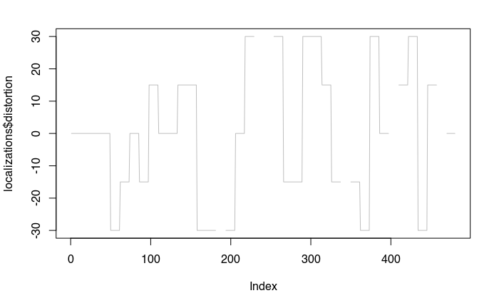

```r
plot(localizations$distortion, type='l', col='gray')
```

```r
for (rotchange.idx in rotchanges) {

  initial_localization <- mu[rotchange.idx+1]

  if (localizations$distortion[rotchange.idx+1] == 0) next() # skip shifting to 0?

  # confidence interval needs to have all participants responses to be reliable?
  # let's assume normality, so we don't bootstrap:

  data <- as.vector(as.matrix(localizations[c((rotchange.idx+9):(rotchange.idx+12)),c(2:33)]))
  data <- colMeans( localizations[c((rotchange.idx+9):(rotchange.idx+12)),c(2:33)], na.rm=TRUE )
  data <- data[is.finite(data)]
  #print(data)

  cat(sprintf('\ntrial: %d, rotation: %d, (change: %d)  \n',rotchange.idx+1, localizations$distortion[rotchange.idx+1], diff(localizations$distortion[c((rotchange.idx-1):(rotchange.idx))])))
  CI <- SMCL::getConfidenceInterval(data=data)
  cat(sprintf('CI: low %0.4f  hi %0.4f\n',CI[1], CI[2]))
  for (trialadd in c(1:4)) {
    if (mu[rotchange.idx+trialadd] > min(CI) & mu[rotchange.idx+trialadd] < max(CI)) {
      cat(sprintf('WITHIN: trial %d: localization: %0.4f\n', trialadd, mu[rotchange.idx+trialadd]))
    } else {
      cat(sprintf('OUTSIDE: trial %d: localization: %0.4f\n', trialadd, mu[rotchange.idx+trialadd]))
    }
  }

}
```

```
trial: 51, rotation: -30, (change: -30)
CI: low -10.6270  hi -4.1322
WITHIN: trial 1: localization: -5.7612
WITHIN: trial 2: localization: -5.5008
OUTSIDE: trial 3: localization: -3.5695
WITHIN: trial 4: localization: -5.3613

trial: 63, rotation: -15, (change: 15)
CI: low -10.3410  hi -1.8913
WITHIN: trial 1: localization: -6.2790
WITHIN: trial 2: localization: -9.3947
WITHIN: trial 3: localization: -8.4042
OUTSIDE: trial 4: localization: -10.4405

trial: 87, rotation: -15, (change: -15)
CI: low -8.9356  hi -3.7525
WITHIN: trial 1: localization: -6.4709
WITHIN: trial 2: localization: -7.7608
WITHIN: trial 3: localization: -7.2173
OUTSIDE: trial 4: localization: -1.0720

trial: 99, rotation: 15, (change: 30)
CI: low 0.0369  hi 6.7188
OUTSIDE: trial 1: localization: -2.3317
WITHIN: trial 2: localization: 3.2402
WITHIN: trial 3: localization: 2.8012
OUTSIDE: trial 4: localization: -1.7754

trial: 135, rotation: 15, (change: 15)
CI: low 1.3897  hi 6.2295
WITHIN: trial 1: localization: 5.9595
WITHIN: trial 2: localization: 3.4564
WITHIN: trial 3: localization: 3.8068
WITHIN: trial 4: localization: 5.8998

trial: 159, rotation: -30, (change: -45)
CI: low -10.3227  hi -5.2778
OUTSIDE: trial 1: localization: -4.5329
WITHIN: trial 2: localization: -9.8602
OUTSIDE: trial 3: localization: -12.6662
```

[output cut: 56 more lines]

```
WITHIN: trial 4: localization: 4.2769

trial: 435, rotation: -30, (change: -60)
CI: low -5.4368  hi -1.5616
WITHIN: trial 1: localization: -2.6218
OUTSIDE: trial 2: localization: -6.8364
WITHIN: trial 3: localization: -5.2617
OUTSIDE: trial 4: localization: -5.7405

trial: 447, rotation: 15, (change: 45)
CI: low 0.4864  hi 4.4948
WITHIN: trial 1: localization: 0.9862
OUTSIDE: trial 2: localization: -1.2572
WITHIN: trial 3: localization: 2.0415
WITHIN: trial 4: localization: 2.6447
```